# Building a Machine Learning Model Workflow

1. Introduction
2. Build a machine learning model
3. PACE: Plan
4. PACE: Analyze
5. PACE: Construct
6. PACE: Execute

[figure not shown]

# Introduction

- I am close to completing this user churn project. Previously, I completed a project proposal, used Python to explore and analyze Waze’s user data, created data visualizations, and conducted a hypothesis test. Most recently, I built a binomial logistic regression model based on multiple variables.
- Now I will build a machine learning model to predict user churn. To get the best results, I will build and test two tree-based models: **random forest** and **XGBoost**.
- My work will help leadership make informed business decisions to prevent user churn, improve user retention, and grow Waze’s business.

**The Purpose**:

> - To find factors that drive user churn.

**The Goal**:

> - To predict whether or not a Waze user is retained or churned.

*This project has three parts:*

**Part 1:** Ethical Considerations

- Consider the ethical implications of the request
- Should the objective of the model be adjusted?

**Part 2:** Feature Engineering

- Perform feature selection, extraction, and transformation to prepare the data for modeling

**Part 3:**

- Build the models, evaluate them, and advise on next steps

# Build a machine learning model

# **PACE stages**

The following notebook components are labeled with the respective **PACE** stage: `Plan`, `Analyze`, `Construct`, and `Execute`.

## **PACE: Plan**

In this stage I'll consider the following questions:

1. What am I being asked to do?
> - *Predict if a customer will churn or be retained.*
2. What are the ethical implications of the model? What are the consequences of my model making errors?
- What is the likely effect of the model when it predicts a false negative (i.e., when the model says a Waze user won't churn, but they actually will)?

> *Waze will fail to take proactive measures to retain users who are likely to stop using the app. For example, Waze might proactively push an app notification to users, or send a survey to better understand user dissatisfaction.*
- What is the likely effect of the model when it predicts a false positive (i.e., when the model says a Waze user will churn, but they actually won't)?
> - *Waze may take proactive measures to retain users who are NOT likely to churn. This may lead to an annoying or negative experience for loyal users of the app.*
3. Do the benefits of such a model outweigh the potential problems?

> *The proactive measueres taken by Waze might have unintended effects on users, and these effects might encourage user churn. Follow-up analysis on the effectiveness of the measures will be recommended. If the measures are reasonable and effective, then the benefits will most likely outweigh the problems.*
4. Would I proceed with the request to build this model? Why or why not?

> *Yes. There aren't any significant risks for building such a model.*

### Step 1. Imports and data loading

```python
# Importing packages for data manipulation
import numpy as np
import pandas as pd

# Importing packages for data visualization
import matplotlib.pyplot as plt

# Allows me to see all of the columns, preventing Juptyer from redacting them.
pd.set_option('display.max_columns', None)

# Importing packages for data modeling
from sklearn.model_selection import GridSearchCV, train_test_split
from sklearn.metrics import roc_auc_score, roc_curve, auc
from sklearn.metrics import accuracy_score, precision_score, recall_score,\
f1_score, confusion_matrix, ConfusionMatrixDisplay, RocCurveDisplay, PrecisionRecallDisplay

from sklearn.ensemble import RandomForestClassifier
from xgboost import XGBClassifier

# This function helps plot feature importance
from xgboost import plot_importance

# This module saves the models once I fit them.
import pickle
```

Ill read in the dataset as `df0` and inspect the first five rows

```python
# Importing the dataset
df0 = pd.read_csv('waze_dataset.csv')
```

```python
# Inspecting the first five rows
df0.head()
```

|  | ID | label | sessions | drives | total_sessions | n_days_after_onboarding | total_navigations_fav1 | total_navigations_fav2 | driven_km_drives | duration_minutes_drives | activity_days | driving_days | device |
| --- | --- | --- | --- | --- | --- | --- | --- | --- | --- | --- | --- | --- | --- |
| 0 | 0 | retained | 283 | 226 | 296.748273 | 2276 | 208 | 0 | 2628.845068 | 1985.775061 | 28 | 19 | Android |
| 1 | 1 | retained | 133 | 107 | 326.896596 | 1225 | 19 | 64 | 13715.920550 | 3160.472914 | 13 | 11 | iPhone |
| 2 | 2 | retained | 114 | 95 | 135.522926 | 2651 | 0 | 0 | 3059.148818 | 1610.735904 | 14 | 8 | Android |
| 3 | 3 | retained | 49 | 40 | 67.589221 | 15 | 322 | 7 | 913.591123 | 587.196542 | 7 | 3 | iPhone |
| 4 | 4 | retained | 84 | 68 | 168.247020 | 1562 | 166 | 5 | 3950.202008 | 1219.555924 | 27 | 18 | Android |

## **PACE: Analyze**

### Step 2. Feature engineering

I have already prepared much of this data and performed exploratory data analysis (EDA) in previous projects. I know that some features had stronger correlations with churn than others, and I also created some features that may be useful.

In this part of the project, I'll engineer these features and some new features to use for modeling.

To begin, I'll create a copy of `df0` to preserve the original dataframe and call the copy `df`.

```python
# Copying the df0 dataframe
df = df0.copy()
```

I'll call `info()` on the new DataFrame so the existing columns can be easily referenced.

```python
df.info()
```

```
<class 'pandas.core.frame.DataFrame'>
RangeIndex: 14999 entries, 0 to 14998
Data columns (total 13 columns):
 #   Column                   Non-Null Count  Dtype
---  ------                   --------------  -----
 0   ID                       14999 non-null  int64
 1   label                    14299 non-null  object
 2   sessions                 14999 non-null  int64
 3   drives                   14999 non-null  int64
 4   total_sessions           14999 non-null  float64
 5   n_days_after_onboarding  14999 non-null  int64
 6   total_navigations_fav1   14999 non-null  int64
 7   total_navigations_fav2   14999 non-null  int64
 8   driven_km_drives         14999 non-null  float64
 9   duration_minutes_drives  14999 non-null  float64
 10  activity_days            14999 non-null  int64
 11  driving_days             14999 non-null  int64
 12  device                   14999 non-null  object
dtypes: float64(3), int64(8), object(2)
memory usage: 1.5+ MB
```

Now, I'll create a feature representing the mean number of kilometers driven on each driving day in the last month for each user and this feature as a column to `df`.

```python
# 1. Creating the `km_per_driving_day` feature
df['km_per_driving_day'] = df['driven_km_drives'] / df['driving_days']

# 2. Getting descriptive stats
df['km_per_driving_day'].describe()
```

```
count    1.499900e+04
mean              inf
std               NaN
min      3.022063e+00
25%      1.672804e+02
50%      3.231459e+02
75%      7.579257e+02
max               inf
Name: km_per_driving_day, dtype: float64
```

**Observation**:

> - I notice that some values are infinite. This is the result of there being values of zero in the `driving_days` column. Pandas imputes a value of infinity in the corresponding rows of the new column because division by zero is undefined.

I'll convert these values from infinity to zero. I'll use `np.inf` to refer to a value of infinity.

```python
# 1. Converting infinite values to zero
df.loc[df['km_per_driving_day']==np.inf, 'km_per_driving_day'] = 0

# 2. Confirming that it worked
df['km_per_driving_day'].describe()
```

```
count    14999.000000
mean       578.963113
std       1030.094384
min          0.000000
25%        136.238895
50%        272.889272
75%        558.686918
max      15420.234110
Name: km_per_driving_day, dtype: float64
```

I'll now create a new column **`precent_sessions_in_the_last_month`** that represents the percentage of each user's total sessions that were logged in their last month of use.

```python
# 1. Creating the `percent_sessions_in_last_month` feature
df['percent_sessions_in_last_month'] = df['sessions'] / df['total_sessions']

# 2. Getting descriptive stats
df['percent_sessions_in_last_month'].describe()
```

```
count    14999.000000
mean         0.449255
std          0.286919
min          0.000000
25%          0.196221
50%          0.423097
75%          0.687216
max          1.530637
Name: percent_sessions_in_last_month, dtype: float64
```

Next, I'll create a new binary feature called **`professional_driver`** that is a `1` for users who had 60 or more drives **and** drove on 15+ days in the last month.

**Note:** The objective here is to create a new feature that separates professional drivers from other drivers. In this case, domain knowledge and intuition are used to determine these deciding thresholds, but ultimately they are arbitrary.

To create this column I'll use the `np.where()` function. This function accepts as agruments:

1. A condition
2. What to return when the condition is true.
3. What to return when the condition is false.

```
Example:
x = [1, 2, 3]
x = np.where(x > 2, 100, 0)
x
array([  0,   0, 100])
```

```python
# Creating the `professional_driver` feature
df['professional_driver'] = np.where((df['drives'] >= 60) & (df['driving_days'] >= 15), 1, 0)
```

Now, I'll create a new column **`total_sessions_per_day`** that represents the mean number of sessions per day since onboarding.

```python
# Creating the `total_sessions_per_day` feature
df['total_sessions_per_day'] = df['total_sessions'] / df['n_days_after_onboarding']

# Getting descriptive stats
df['total_sessions_per_day'].describe()
```

```
count    14999.000000
mean         0.338698
std          1.314333
min          0.000298
25%          0.051037
50%          0.100775
75%          0.216269
max         39.763874
Name: total_sessions_per_day, dtype: float64
```

Next, I'll create a column **`km_per_hour`** representing the mean kilometers per hour driven in the last month.

```python
# Creating the `km_per_hour` feature
df['km_per_hour'] = df['driven_km_drives'] / (df['duration_minutes_drives'] / 60)
# Getting descriptive stats
df['km_per_hour'].describe()
```

```
count    14999.000000
mean       190.394608
std        334.674026
min         72.013095
25%         90.706222
50%        122.382022
75%        193.130119
max      23642.920871
Name: km_per_hour, dtype: float64
```

These numbers are obviously problematic, and it would be worthwhile to seek clarification from Waze regarding how these features are collected to better understand why such unrealistic speeds are observed.

Next I'll create a new column **`km_per_drive`** representing the mean number of kilometers per drive made in the last month for each user.

```python
# Creating the `km_per_drive` feature
df['km_per_drive'] = df['driven_km_drives'] / df['drives']
# Getting descriptive stats
df['km_per_drive'].describe()
```

```
count    1.499900e+04
mean              inf
std               NaN
min      1.008775e+00
25%      3.323065e+01
50%      7.488006e+01
75%      1.854667e+02
max               inf
Name: km_per_drive, dtype: float64
```

**Observation**:

> - This feature has infinite values as well. I'll convert the infinite values to zero, then confirm that it worked.

```python
# 1. Converting infinite values to zero
df.loc[df['km_per_drive']==np.inf, 'km_per_drive'] = 0

# 2. Confirming that it worked
df['km_per_drive'].describe()
```

```
count    14999.000000
mean       232.817946
std        620.622351
min          0.000000
25%         32.424301
50%         72.854343
75%        179.347527
max      15777.426560
Name: km_per_drive, dtype: float64
```

Finally, I'll create a new column **`percent_of_sessions_to_favorite`** that represents the percentage of total sessions that were used to navigate to one of the users' favorite places.

This is a proxy representation for the percent of overall drives that are to a favorite place. Since total drives since onboarding are not contained in this dataset, total sessions must serve as a reasonable approximation.

People whose drives to non-favorite places that make up a higher percentage of their total drives might be less likely to churn, since they're making more drives to less familiar places.

```python
# Creating the `percent_of_sessions_to_favorite` feature
df['percent_of_drives_to_favorite'] = (
    df['total_navigations_fav1'] + df['total_navigations_fav2']) / df['total_sessions']

# Getting descriptive stats
df['percent_of_drives_to_favorite'].describe()
```

```
count    14999.000000
mean         1.665439
std          8.865666
min          0.000000
25%          0.203471
50%          0.649818
75%          1.638526
max        777.563629
Name: percent_of_drives_to_favorite, dtype: float64
```

### Step 3. Dropping missing values

Because I know from previous EDA that there is no evidence of a non-random cause of the 700 missing values in the `label` column, and because these observations comprise less than 5% of the data, I'll use the `dropna()` method to drop the rows that are missing this data.

```python
# Dropping rows with missing values
df = df.dropna(subset=['label'])
```

### Step 4. Outliers

I know from previous EDA that many of these columns have outliers. However, tree-based models are resilient to outliers, so there is no need for me to make any imputations.

### Step 5. Variable encoding

In order to use `device` as an X variable, I will need to convert it to binary, since this variable is categorical. Because this dataset has only one remaining categorical feature(`device`), I can just implement the transformation directly instead of calling special functions.

I'll assign a `0` for all Android devices

I'll assign a `1` for all iPhone devices

This new binary column will be saved as `device2`so as not to overwrite the original `device` variable.

```python
# Creating a new `device2` variable
df['device2'] = np.where(df['device']=='Android', 0, 1)
df[['device', 'device2']].tail()
```

|  | device | device2 |
| --- | --- | --- |
| 14994 | iPhone | 1 |
| 14995 | Android | 0 |
| 14996 | iPhone | 1 |
| 14997 | iPhone | 1 |
| 14998 | iPhone | 1 |

### Target encoding

The target variable is also categorical, since a user is labeled as either "churned" or "retained." I'll change the data type of the label column to be binary. This change is needed to train the models.

I'll assign a `0` for all `retained` users

I'll assign a `1` for all `churned` users

This new binary column will be saved as `label2` so as not to overwrite the original `label` variable.

```python
# Creating a binary 'label2' column
df['label2'] = np.where(df['label']=='churned', 1, 0)
df[['label', 'label2']].tail()
```

|  | label | label2 |
| --- | --- | --- |
| 14994 | retained | 0 |
| 14995 | retained | 0 |
| 14996 | retained | 0 |
| 14997 | churned | 1 |
| 14998 | retained | 0 |

### Step 6. Feature selection

Tree-based models can handle multicollinearity, so the only feature within this dataset that can be cut is `ID`, since it does not contain any information releveant to churn. However, `device` won't be used simply because it's a copy of `device2`.

```python
# Dropping the `ID` column
df = df.drop(['ID'], axis=1)
```

### Step 7. Evaluation metric

Before modeling, I must decide on an evaluation metric. This will depend on the class balance of the target variable and the use case of the model.

First, I'll need to examine the class balance of the target variable.

```python
# Getting class balance of the 'label' column
df['label'].value_counts(normalize=True)
```

```
label
retained    0.822645
churned     0.177355
Name: proportion, dtype: float64
```

**Observations**:

> - Approximately `18%` of the users in this dataset churned. This is an unbalanced dataset, but not extremely so. It can be modeled without any class rebalancing.
> - Considering which evaluation metric is best, accuracy might not be the best gauge of performance because a model can have high accuracy on an imbalanced dataset and still fail to predict the minority class.
> - It was already determined that the risks involved in making a false positive prediction are minimal. No one stands to get hurt, lose money, or suffer any other significant consequence if they are predicted to churn. Therefore, I'll select the model based on the recall score.

## **PACE: Construct**

### Step 8. Modeling workflow and model selection process

The final modeling dataset contains `14,299` samples. This is towards the lower end of what might be considered sufficient to conduct a robust model selection process, but still doable. I'll now outline my next steps in this process:

> 1. Split the data into train/validation/test sets (`60/20/20`)

```
- Note that, when deciding on the split ratio and whether or not to use a validation set to select a champion model, I consider both how many samples will be in each data partition, and how many examples of the minority class each would therefore contain. In this case, a `60/20/20` split would result in `2,860` samples in the validation set and the same number in the test set, of which `18%` or `515` samples—would represent users who churn.
```

> 2. Fit models and tune hyperparameters on the training set.
> 3. Perform final model selection on the validation set.
> 4. Assess the champion model's performance on the test.

[figure not shown]

### Step 9. Split the data

Now I am ready to model. The only remaining step here is to split the data into features/target variable and training/validation/test sets. My next steps in this process are to:

> 1. Define a variable `X` that isolates the features.
> 2. Define a variable `y` that isolates the target variable (`label2`).
> 3. Split the data 80/20 into an interim training set and a test set. I'll also stratify the splits and set the random state to `42`.
> 4. Split the interim training set `75/25` into a training set and a validation set, yielding a final ratio of `60/20/20` for training/validation/test sets. Again, I'll stratify the splits and set the random state to `42`.

```python
# 1. Isolating 'X' variables
X = df.drop(columns=['label', 'label2', 'device'])

# 2. Isolating the 'y' variable
y = df['label2']

# 3. Splitting into train and test sets
X_tr, X_test, y_tr, y_test = train_test_split(X, y, stratify=y,
                                              test_size=0.2, random_state=42)

# 4. Splitting into train and validate sets
X_train, X_val, y_train, y_val = train_test_split(X_tr, y_tr, stratify=y_tr,
                                                  test_size=0.25, random_state=42)
```

```python
# Verifying th number of samples in the partitioned data
for x in [X_train, X_val, X_test]:
    print(len(x))
```

```
8579
2860
2860
```

**Observation**:

> - This aligns with expectations.

### Step 10. Modeling

**Random forest**

I'll begin using `GridSearch` to tune a random forest model. My next steps in this process are to:

> 1. Instantiate the random forest classifier rf and set the random state.
> 2. Create a dictionary `cv_params` of any of the following hyperparameters and their corresponding values to tune. The more I tune, the better the model will fit the data, but the longer it will take.

```
- `max_depth`
- `max_feaures`
- `max_samples`
- `min_samples_leaf`
- `min_samples_split`
- `n_estimators`
```

> 3. Define a list `scoring` of scoring metrics for GridSearch to capture (precision, recall, F1 score, and accuracy).
> 4. Instantiate the `GridSearchCV` object `rf_cv`. Pass to it as arguments:

```
- estimator=`rf`
- param_grid=`cv_params`
- scoring=`scoring`
- cv: define the number of cross-validation folds I want (`cv=_`)
- refit: indicate which evaluation metric I want to use to select the model (`refit=_`)
```

- I'll set `refit` to `'recall'`.

**Note:** To save time, this project doesn't use multiple values for each parameter in the grid search, otherwise I would include a range of values in the search to hone in on the best set of parameters.

```python
# 1. Instantiating the random forest classifier
rf = RandomForestClassifier(random_state=42)

# 2. Creating a dictionary of hyperparameters to tune
cv_params = {'max_depth': [None],
             'max_features': [1.0],
             'max_samples': [1.0],
             'min_samples_leaf': [2],
             'min_samples_split': [2],
             'n_estimators': [300],
             }

# 3. Defining a list of scoring metrics to capture
scoring = ['accuracy', 'precision', 'recall', 'f1']

# 4. Instantiating the GridSearchCV object
rf_cv = GridSearchCV(rf, cv_params, scoring=scoring, cv=4, refit='recall')
```

Now, I'll fit the model to the training data.

```python
%%time
rf_cv.fit(X_train, y_train)
```

```
Wall time: 1min 3s
```

```
GridSearchCV(cv=4, estimator=RandomForestClassifier(random_state=42),
             param_grid={'max_depth': [None], 'max_features': [1.0],
                         'max_samples': [1.0], 'min_samples_leaf': [2],
                         'min_samples_split': [2], 'n_estimators': [300]},
             refit='recall', scoring=['accuracy', 'precision', 'recall', 'f1'])
```

I'll now examine the best average score across all the validation folds.

```python
# Examining best score
rf_cv.best_score_
```

```
0.12678201409034398
```

Examining the best combination of hyperparameters

```python
# Examining best hyperparameter combo
rf_cv.best_params_
```

```
{'max_depth': None,
 'max_features': 1.0,
 'max_samples': 1.0,
 'min_samples_leaf': 2,
 'min_samples_split': 2,
 'n_estimators': 300}
```

Next, I'll use the `make_results()` function to output all of the scores of this model.

```python
def make_results(model_name:str, model_object, metric:str):
    '''
    Arguments:
        model_name (string): what I want the model to be called in the output table
        model_object: a fit GridSearchCV object
        metric (string): precision, recall, f1, or accuracy

    Returns a pandas df with the F1, recall, precision, and accuracy scores
    for the model with the best mean 'metric' score across all validation folds.
    '''

    # Creating a dictionary that maps input metric to actual metric name in GridSearchCV
    metric_dict = {'precision': 'mean_test_precision',
                   'recall': 'mean_test_recall',
                   'f1': 'mean_test_f1',
                   'accuracy': 'mean_test_accuracy',
                   }

    # Getting all the results from the CV and putting them in a df
    cv_results = pd.DataFrame(model_object.cv_results_)

    # Isolating the row of the df with the max(metric) score
    best_estimator_results = cv_results.iloc[cv_results[metric_dict[metric]].idxmax(), :]

    # Extracting accuracy, precision, recall, and f1 score from that row
    f1 = best_estimator_results.mean_test_f1
    recall = best_estimator_results.mean_test_recall
    precision = best_estimator_results.mean_test_precision
    accuracy = best_estimator_results.mean_test_accuracy

    # Creating a table of results
    table = pd.DataFrame({'model': [model_name],
                          'precision': [precision],
                          'recall': [recall],
                          'F1': [f1],
                          'accuracy': [accuracy],
                          },
                         )

    return table
```

Passing the `GridSearch` object to the `make_results()` function.

```python
results = make_results('RF cv', rf_cv, 'recall')
results
```

|  | model | precision | recall | F1 | accuracy |
| --- | --- | --- | --- | --- | --- |
| 0 | RF cv | 0.457163 | 0.126782 | 0.198445 | 0.81851 |

**Observations**:

> - Asside from the accuracy, the scores aren't that good. However, in a previous project when I built the logistic regression model the recall was `0.09`, which means that this model has `33%` better recall and about the same accuracy, and it was trained on less data.
> - Here I could try retuning the hyperparameters to try to get a better score, this may marginally improve the model, however I'll proceed with the project.

**XGBoost**

I'll try to improve the scores using an XGBoost model. My next steps in this process are to:

> 1. Instantiate the XGBoost classifier `xgb` and set `objective='binary:logistic'`. I'll also set the random state.
> 2. Create a dictionary `cv_params` of the following hyperparameters and their corresponding values to tune:

```
- `max_depth`
- `min_child_weight`
- `learning_rate`
- `n_estimators`
```

> 3. Define a list `scoring` of scoring metrics for grid search to capture (precision, recall, F1 score, and accuracy).
> 4. Instantiate the `GridSearchCV` object `xgb_cv` and Pass to it arguments:

```
- estimator=`xgb`
- param_grid=`cv_params`
- scoring=`scoring`
- cv: define the number of cross-validation folds I want (`cv=_`)
- refit: indicate which evaluation metric I want to use to select the model (`refit='recall'`)
```

```python
# 1. Instantiating the XGBoost classifier
xgb = XGBClassifier(objective='binary:logistic', random_state=42)

# 2. Creating a dictionary of hyperparameters to tune
cv_params = {'max_depth': [6, 12],
             'min_child_weight': [3, 5],
             'learning_rate': [0.01, 0.1],
             'n_estimators': [300]
             }

# 3. Defining a list of scoring metrics to capture
scoring = ['accuracy', 'precision', 'recall', 'f1']

# 4. Instantiating the GridSearchCV object
xgb_cv = GridSearchCV(xgb, cv_params, scoring=scoring, cv=4, refit='recall')
```

Now I'll fit the model to the `X_train` and `y_train` data.

```python
%%time
xgb_cv.fit(X_train, y_train)
```

```
Wall time: 21.5 s
```

```
GridSearchCV(cv=4,
             estimator=XGBClassifier(base_score=None, booster=None,
                                     callbacks=None, colsample_bylevel=None,
                                     colsample_bynode=None,
                                     colsample_bytree=None, device=None,
                                     early_stopping_rounds=None,
                                     enable_categorical=False, eval_metric=None,
                                     feature_types=None, gamma=None,
                                     grow_policy=None, importance_type=None,
                                     interaction_constraints=None,
                                     learning_rate=None,...
                                     max_delta_step=None, max_depth=None,
                                     max_leaves=None, min_child_weight=None,
                                     missing=nan, monotone_constraints=None,
                                     multi_strategy=None, n_estimators=None,
                                     n_jobs=None, num_parallel_tree=None,
                                     random_state=42, ...),
             param_grid={'learning_rate': [0.01, 0.1], 'max_depth': [6, 12],
                         'min_child_weight': [3, 5], 'n_estimators': [300]},
             refit='recall', scoring=['accuracy', 'precision', 'recall', 'f1'])
```

Getting the best score from this model.

```python
# Examining best score
xgb_cv.best_score_
```

```
0.1708264263019754
```

Getting the best parameters.

```python
# Examining best parameters
xgb_cv.best_params_
```

```
{'learning_rate': 0.1,
 'max_depth': 6,
 'min_child_weight': 5,
 'n_estimators': 300}
```

Again, I'll use the `make_results()` function to output all of the scores of this model. Note that this function accepts three agruments.

```python
# Calling the 'make_results()' on the GridSearch object
xgb_cv_results = make_results('XGB cv', xgb_cv, 'recall')
results = pd.concat([results, xgb_cv_results], axis=0)
results
```

|  | model | precision | recall | F1 | accuracy |
| --- | --- | --- | --- | --- | --- |
| 0 | RF cv | 0.457163 | 0.126782 | 0.198445 | 0.818510 |
| 0 | XGB cv | 0.425932 | 0.170826 | 0.243736 | 0.811866 |

### Step 11. Model selection

Now, I'll use the best random forest model and the best XGBoost model to predict on the validation data. Whichever performs better will be selected as the champion model.

**Random forest**

```python
# Using the random forest model to predict on validation data
rf_val_preds = rf_cv.best_estimator_.predict(X_val)
```

I'll use the `get_test_scores()` function to generate a table of scores from the predictions on the validation data.

```python
def get_test_scores(model_name:str, preds, y_test_data):
    '''
    Generate a table of test scores.

    In:
        model_name (string): My choice: how the model will be named in the output table
        preds: numpy array of test predictions
        y_test_data: numpy array of y_test data

    Out:
        table: a pandas df of precision, recall, f1, and accuracy scores for my model
    '''
    accuracy = accuracy_score(y_test_data, preds)
    precision = precision_score(y_test_data, preds)
    recall = recall_score(y_test_data, preds)
    f1 = f1_score(y_test_data, preds)

    table = pd.DataFrame({'model': [model_name],
                          'precision': [precision],
                          'recall': [recall],
                          'F1': [f1],
                          'accuracy': [accuracy]
                          })

    return table
```

```python
# Getting validation scores for RF model
rf_val_scores = get_test_scores('RF val', rf_val_preds, y_val)

# Appending to the results table
results = pd.concat([results, rf_val_scores], axis=0)
results
```

|  | model | precision | recall | F1 | accuracy |
| --- | --- | --- | --- | --- | --- |
| 0 | RF cv | 0.457163 | 0.126782 | 0.198445 | 0.818510 |
| 0 | XGB cv | 0.425932 | 0.170826 | 0.243736 | 0.811866 |
| 0 | RF val | 0.445255 | 0.120316 | 0.189441 | 0.817483 |

**Observations**:

> - Notice that the scores went down from the training scores across all metrics, but only by very little. This means that the model did not overfit the training data.

**XGBoost**

Now I'll do the same thing to get the performance scores of the XGBoost model on the validation data.

```python
# Using the XGBoost model to predict on validation data
xgb_val_preds = xgb_cv.best_estimator_.predict(X_val)

# Getting validation scores for XGBoost model
xgb_val_scores = get_test_scores('XGB val', xgb_val_preds, y_val)

# Appending to the results table
results = pd.concat([results, xgb_val_scores], axis=0)
results
```

|  | model | precision | recall | F1 | accuracy |
| --- | --- | --- | --- | --- | --- |
| 0 | RF cv | 0.457163 | 0.126782 | 0.198445 | 0.818510 |
| 0 | XGB cv | 0.425932 | 0.170826 | 0.243736 | 0.811866 |
| 0 | RF val | 0.445255 | 0.120316 | 0.189441 | 0.817483 |
| 0 | XGB val | 0.422680 | 0.161736 | 0.233951 | 0.812238 |

**Observations**:

> - Just like with the random forest model, the XGBoost model's validation scores were lower, but only very slightly. It is still the clear champion.

## **PACE: Execute**

### Step 12. Using the champion model to predict on test data

Now I'll use the champion model to predict on the test dataset. This is to give a final indication of how I should expect the model to perform on new future data, should I decide to use the model.

```python
# Using the XGBoost model to predict on test data
xgb_test_preds = xgb_cv.best_estimator_.predict(X_test)

# Getting test scores for XGBoost model
xgb_test_scores = get_test_scores('XGB test', xgb_test_preds, y_test)

# Appending to the results table
results = pd.concat([results, xgb_test_scores], axis=0)
results
```

|  | model | precision | recall | F1 | accuracy |
| --- | --- | --- | --- | --- | --- |
| 0 | RF cv | 0.457163 | 0.126782 | 0.198445 | 0.818510 |
| 0 | XGB cv | 0.425932 | 0.170826 | 0.243736 | 0.811866 |
| 0 | RF val | 0.445255 | 0.120316 | 0.189441 | 0.817483 |
| 0 | XGB val | 0.422680 | 0.161736 | 0.233951 | 0.812238 |
| 0 | XGB test | 0.423963 | 0.181460 | 0.254144 | 0.811189 |

**Observations**:

> - The precision, recall and F1 scores improved slightly, however the accuracy score declined slightly against the validation set. Nonetheless, this is stil within the acceptable range for performance discrepancy between validation and test scores.

### Step 13. Confusion matrix

Next I'll plot a confusion matrix of the champion model's predictions on the test data.

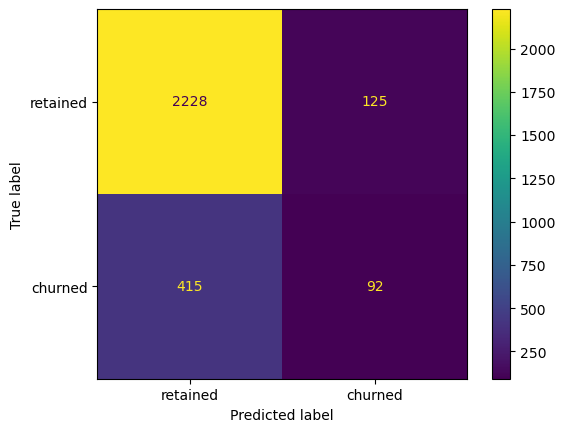

```python
# Generate array of values for confusion matrix
cm = confusion_matrix(y_test, xgb_test_preds, labels=xgb_cv.classes_)

# Plot confusion matrix
disp = ConfusionMatrixDisplay(confusion_matrix=cm,
                             display_labels=['retained', 'churned'])
disp.plot();
```

**Observations**:

> - The model predicted over three times as many false negatives than it did false positives, and it correctly identified only `18.1%` of the users who actually churned.

### Step 14. Feature importance

I use the `plot_importance` function to inspect the most important features of the final model.

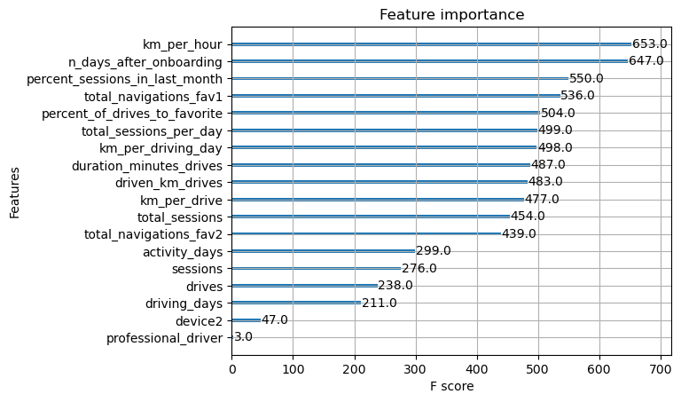

```python
plot_importance(xgb_cv.best_estimator_);
```

**Observations**:

> - The XGBoost model made more use of many of the features than did the logistic regression model from the previous project, which weighted a single feature (`activity_days`) very heavily in its final prediction.
> - If anything, this underscores the importance of feature engineering. Notice that engineered features accounted for six of the top 10 features (and three of the top five). Feature engineering is often one of the best and easiest ways to boost model performance.
> - Also, note that the important features in one model might not be the same as the important features in another model. That's why I don't discount features as unimportant without thoroughly examining them and understanding their relationship with the dependent variable, if possible. These discrepancies between features selected by models are typically caused by complex feature interactions.
> - Machine learning is a powerful tool, but it is not magic. In this case the data does not contain predictive signal, even the most complex algorithm will not be able to deliver consistent and accurate predictions.

### Step 15. Conclusion

Now that I've built and tested multiple machine learning models, the next step is to share my findings with the Waze leadership team. Considering key points to share with the team and what information is most relevant to this project include:

1. **Recommendations on using this model**:
   - *It depends. What would the model be used for? If it's used to drive consequential business decisions, then no. The model is not a strong enough predictor, as made clear by its poor recall score. However, if the model is only being used to guide further exploratory efforts, then it can have value.*
2. **Tradeoffs made by splitting the data into training, validation and test sets as opposed to just training and test sets**:
   - *Splitting the data three ways means that there is less data available to train the model than splitting just two ways. However, performing model selection on a separate validation set enables testing of the champion model by itself on the test set, which gives a better estimate of future performance than splitting the data two ways and selecting a champion model by performance on the test data.*
3. **Benefits of using a logistic regression model over an ensemble of tree-based models (like random forest or XGBoost) for classification tasks**:
   - *Logistic regression models are easier to interpret. Because they assign coefficients to predictor variables, they reveal not only which features factored most heavily into their final predictions, but also the directionality of the weight. In other words, they tell you if each feature is positively or negatively correlated with the target in the model's final prediction.*
4. **Benefits of using an ensemble of tree-based models like random forest or XGBoost over a logistic regression model for classification tasks**:
   - *Tree-based model ensembles are often better predictors. If the most important thing is the predictive power of the model, then tree-based modeling will usually win out against logistic regression (but not always!). They also require much less data cleaning and require fewer assumptions about the underlying distributions of their predictor variables, so they're easier to work with.*
5. **Potential steps to improve this model include**:
   - *New features could be engineered to try to generate better predictive signal, as they often do if you have domain knowledge. In the case of this model, the engineered features made up over half of the top 10 most-predictive features used by the model. It could also be helpful to reconstruct the model with different combinations of predictor variables to reduce noise from unpredictive features.*
6. **Additional features I would like to have to help improve the model include**:
   - *It would be helpful to have drive-level information for each user (such as drive times, geographic locations, etc.). It would probably also be helpful to have more granular data to know how users interact with the app. For example, how often do they report or confirm road hazard alerts? Finally, it could be helpful to know the monthly count of unique starting and ending locations each driver inputs.*

I'll now demonstrate further steps that I could take to tailor the model to this use case.

### Identifying an optimal decision threshold

The default decision threshold for most implementations of classification algorithms—including scikit-learn's—is `0.5`. This means that, in the case of the Waze models, if they predicted that a given user had a `50%` probability or greater of churning, then that user was assigned a predicted value of `1`—the user was predicted to churn.

With imbalanced datasets where the response class is a minority, this threshold might not be ideal. A precision-recall curve can help to visualize the trade-off between this model's precision and recall.

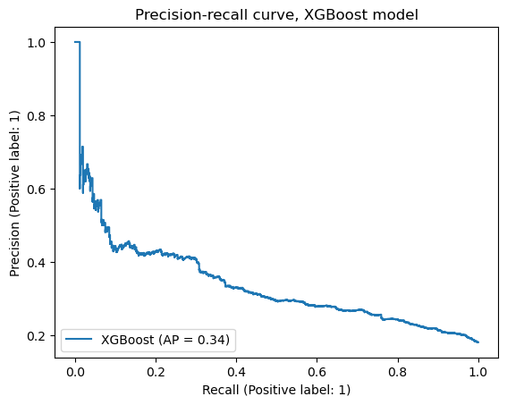

```python
# Plotting the precision-recall curve
display = PrecisionRecallDisplay.from_estimator(
    xgb_cv.best_estimator_, X_test, y_test, name='XGBoost'
    )
plt.title('Precision-recall curve, XGBoost model');
```

**Observations**:

> - As recall increases, precision decreases. But what if I determined that false positives aren't much of a problem? For example, in the case of this Waze project, a false positive could just mean that a user who will not actually churn gets an email and a banner notification on their phone. It's very low risk.

So, what if instead of using the default `0.5` decision threshold of the model, I used a lower threshold?

Here's an example where the threshold is set to `0.4`:

```python
# Getting predicted probabilities on the test data
predicted_probabilities = xgb_cv.best_estimator_.predict_proba(X_test)
predicted_probabilities
```

```
array([[0.94572806, 0.05427194],
       [0.57626796, 0.42373204],
       [0.98132175, 0.01867824],
       ...,
       [0.8135836 , 0.18641636],
       [0.9661311 , 0.03386891],
       [0.7386279 , 0.26137212]], dtype=float32)
```

The `predict_proba()` method returns a 2-D array of probabilities where each row represents a user. The first number in the row is the probability of belonging to the negative class, the second number in the row is the probability of belonging to the positive class. (Notice that the two numbers in each row are complimentary to each other and sum to one.)

I can generate new predictions based on this array of probabilities by changing the decision threshold for what is considered a positive response. For example, the following code converts the predicted probabilities to {`0, 1`} predictions with a threshold of `0.4`. In other words, any users who have a value ≥ `0.4` in the second column will get assigned a prediction of `1`, indicating that they churned.

```python
# Creating a list of just the second column values (probability of target)
probs = [x[1] for x in predicted_probabilities]

# Creating an array of new predictions that assigns a 1 to any value >= 0.4
new_preds = np.array([1 if x >= 0.4 else 0 for x in probs])
new_preds
```

```
array([0, 1, 0, ..., 0, 0, 0])
```

```python
# Getting evaluation metrics for when the threshold is 0.4
get_test_scores('XGB, threshold = 0.4', new_preds, y_test)
```

|  | model | precision | recall | F1 | accuracy |
| --- | --- | --- | --- | --- | --- |
| 0 | XGB, threshold = 0.4 | 0.414986 | 0.284024 | 0.337237 | 0.802098 |

I'll compare these numbers with the results from earlier.

```python
results
```

|  | model | precision | recall | F1 | accuracy |
| --- | --- | --- | --- | --- | --- |
| 0 | RF cv | 0.457163 | 0.126782 | 0.198445 | 0.818510 |
| 0 | XGB cv | 0.425932 | 0.170826 | 0.243736 | 0.811866 |
| 0 | RF val | 0.445255 | 0.120316 | 0.189441 | 0.817483 |
| 0 | XGB val | 0.422680 | 0.161736 | 0.233951 | 0.812238 |
| 0 | XGB test | 0.423963 | 0.181460 | 0.254144 | 0.811189 |

**Observations**:

> - Recall and F1 score increased significantly, while precision and accuracy decreased marginally.
> - So, using the precision-recall curve as a guide, suppose I knew that I'd be satisfied if the model had a recall score of `0.5` and I were willing to accept the `30%` precision score that comes with it. In other words, I'd be happy if the model successfully identified half of the people who will actually churn, even if it means that when the model says someone will churn, it's only correct about `30%`of the time.
> - What threshold will yield this result? There are a number of ways to determine this. Here's one way to do it using a function.

```python
def threshold_finder(y_test_data, probabilities, desired_recall):
    '''
    Find the decision threshold that most closely yields a desired recall score.

    Inputs:
        y_test_data: Array of true y values
        probabilities: The results of the `predict_proba()` model method
        desired_recall: The recall that I want the model to have

    Outputs:
        threshold: The decision threshold that most closely yields the desired recall
        recall: The exact recall score associated with `threshold`
    '''
    probs = [x[1] for x in probabilities]  # Isolating second column of `probabilities`
    thresholds = np.arange(0, 1, 0.001)    # Setting a grid of 1,000 thresholds to test

    scores = []
    for threshold in thresholds:
        # Creating a new array of {0, 1} predictions based on new threshold
        preds = np.array([1 if x >= threshold else 0 for x in probs])
        # Calculating recall score for that threshold
        recall = recall_score(y_test_data, preds)
        # Appending the threshold and its corresponding recall score as a tuple to `scores`
        scores.append((threshold, recall))

    distances = []
    for idx, score in enumerate(scores):
        # Calculating how close each actual score is to the desired score
        distance = abs(score[1] - desired_recall)
        # Appending the (index#, distance) tuple to `distances`
        distances.append((idx, distance))

    # Sorting `distances` by the second value in each of its tuples (least to greatest)
    sorted_distances = sorted(distances, key=lambda x: x[1], reverse=False)
    # Identifying the tuple with the actual recall closest to desired recall
    best = sorted_distances[0]
    # Isolating the index of the threshold with the closest recall score
    best_idx = best[0]
    # Retrieving the threshold and actual recall score closest to desired recall
    threshold, recall = scores[best_idx]

    return threshold, recall
```

Now I'll test the function to find the threshold that results in a recall score closest to `0.5`.

```python
# Getting the predicted probabilities from the champion model
probabilities = xgb_cv.best_estimator_.predict_proba(X_test)

# Calling the function
threshold_finder(y_test, probabilities, 0.5)
```

```
(0.194, 0.4990138067061144)
```

Setting a threshold of `0.194` will result in a recall of `0.499`.

To verify, I can repeat the steps performed earlier to get the other evaluation metrics for when the model has a threshold of `0.194`. Based on the precision-recall curve, a `0.5` recall score should have a precision of `0.3`.

```python
# Creating an array of new predictions that assigns a 1 to any value >= 0.194
probs = [x[1] for x in probabilities]
new_preds = np.array([1 if x >= 0.194 else 0 for x in probs])

# Getting evaluation metrics for when the threshold is 0.194
get_test_scores('XGB, threshold = 0.194', new_preds, y_test)
```

|  | model | precision | recall | F1 | accuracy |
| --- | --- | --- | --- | --- | --- |
| 0 | XGB, threshold = 0.194 | 0.293163 | 0.499014 | 0.369343 | 0.697902 |

**Observations**:

> - It worked! Changing the decision threshold is another tool that can help achieve useful results from a model that may not have been as useful initially.